# 10-Regression Analysis with Time Series

Author

Rick Dean

Abstract

The following notes and scripts are based on the following sources: [Introductory Econometrics - A Modern Approach](https://www.amazon.com/Introductory-Econometrics-Modern-Approach-Standalone/dp/130527010X/ref=sr_1_2?dchild=1&keywords=Introductory+Econometrics%3A+A+Modern+Approach&qid=1597005903&s=books&sr=1-2) by Jeffrey M. Wooldridge is the main text for the statistical content. This text will be referenced as `(Wooldridge)`. The companion text [Using R for Introductory Econometrics](http://www.urfie.net/index.html) by Florian Heiss provides specific R scripts in support of the main text and the inspiration for my scripts, notes and graphics. I will reference this document as `(Heiss)`. The following is from **Part 2 - Regression Analysis with Time Series Data, Chapter 10 Basic Regression Analysis with Time Series Data** of `(Heiss)`.

```r
library(data.table)
library(magrittr)
library(purrr)
library(xts)
library(zoo)
library(dynlm)
library(wooldridge)
library(RregressPkg)
library(RplotterPkg)
library(RtsaPkg)
```

# 10-Regression Analysis with Time Series

## 10.1 Static Time Series Models

Effects of Inflation and Deficits on Interest Rates

Set up the data.

```r
data("intdef", package = "wooldridge")
intdef_dt <- data.table::as.data.table(intdef) %>%
  .[,.(i3, inf, def)] %>%
  data.table::setnames(old = c("i3", "inf","def"), new = c("Interest_Rate","Inflation","Federal_Deficit"))
```

Compute the fitted values and show the coefficient values.

```r
intdef_ols <- RregressPkg::ols_calc(
  df = intdef_dt,
  formula_obj = Interest_Rate ~ Inflation + Federal_Deficit,
  print_detail = T
)
```

```
Interest_Rate ~ Inflation + Federal_Deficit
coef:
    (Intercept)       Inflation Federal_Deficit
         1.7333          0.6059          0.5131

coef se:
    (Intercept)       Inflation Federal_Deficit
         0.4320          0.0821          0.1184
---
n = 56, k = 3
residual se = 1.8432
R-squared = 0.6021
R-squaredAdj = 0.5871
```

Plot the reponse and predictor variables.

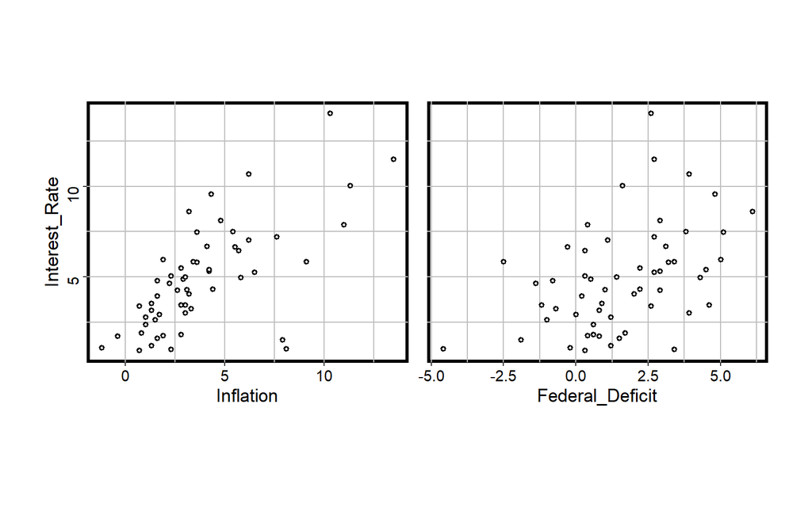

Inflation and Deficits on Interest Rates

```r
build_plot <- function(id, dt, predictors) {
  y_title <- "Interest_Rate"
  hide_y_tics <- FALSE
  if(id == 2){
    y_title <- NULL
    hide_y_tics <- TRUE
  }
  predictor <- predictors[[id]]
  plot_dt <- data.frame(
    x = dt[[predictor]],
    y = dt$Interest_Rate
  )
  aplot <- RplotterPkg::create_scatter_plot(
    df = plot_dt,
    aes_x = "x",
    aes_y = "y",
    x_title = predictor,
    y_title = y_title,
    hide_y_tics = hide_y_tics
  )
  return(aplot)
}
predictors <- c("Inflation","Federal_Deficit")
plot_lst <- purrr::map(1:2,
                       build_plot,
                       dt = intdef_dt,
                       predictors = predictors
)
layout <- list(
  plots = plot_lst,
  rows = c(1, 1),
  cols = c(1, 2)
)

RplotterPkg::multi_panel_grid(
  layout = layout,
  col_widths = c(9.5, 9),
  row_heights = 8
)
```

## 10.2 Time Series Data Types in R

### 10.2.1 Equispaced Time Series in R

Set up the data.

```r
data(barium, package = "wooldridge")
barium_dt <- data.table::as.data.table(barium) %>%
  .[,.(chnimp)]
```

Create a time series (*ts*) object.

```r
imports_ts <- ts(data = barium_dt$chnimp, start = c(1978,2), frequency=12)
str(imports_ts)
```

```
 Time-Series [1:131] from 1978 to 1989: 220.5 94.8 219.4 317.4 114.6 ...
```

Plot the time series.

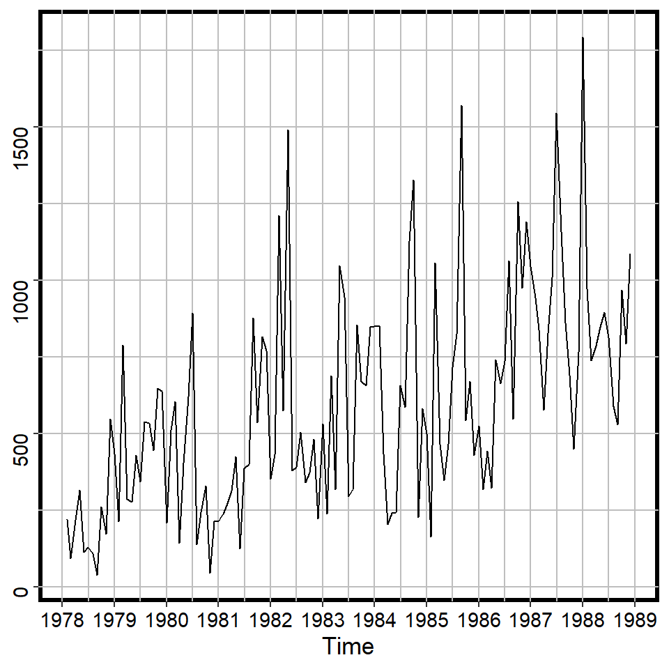

Equispaced Time Series

```r
imports_ts_df <- RtsaPkg::tsObj_to_dt(imports_ts)
RplotterPkg::create_scatter_plot(
  df = imports_ts_df,
  aes_x = "time",
  aes_y = "value",
  x_major_date_breaks = "1 year",
  x_date_labels = "%Y",
  connect = T,
  show_pts = F,
  x_title = "Time"
)
```

### 10.2.2 Irregular Time Series in R

Create time series *zoo* object of the interest rate data.

```r
data("intdef", package = "wooldridge")
int_year_dt <- data.table::as.data.table(intdef) %>%
  .[,.(i3, year)]

int_year_zoo <- zoo::zoo(int_year_dt, order.by = int_year_dt$year, frequency = 12)
str(int_year_zoo)
```

```
'zooreg' series from Jan 1948 to Jan 2003
  Data: num [1:56, 1:2] 1.04 1.1 1.22 1.55 1.77 ...
 - attr(*, "dimnames")=List of 2
  ..$ : NULL
  ..$ : chr [1:2] "i3" "year"
  Index:  'yearmon' num [1:56] Jan 1948 Jan 1949 Jan 1950 Jan 1951 ...
  Frequency: 12
```

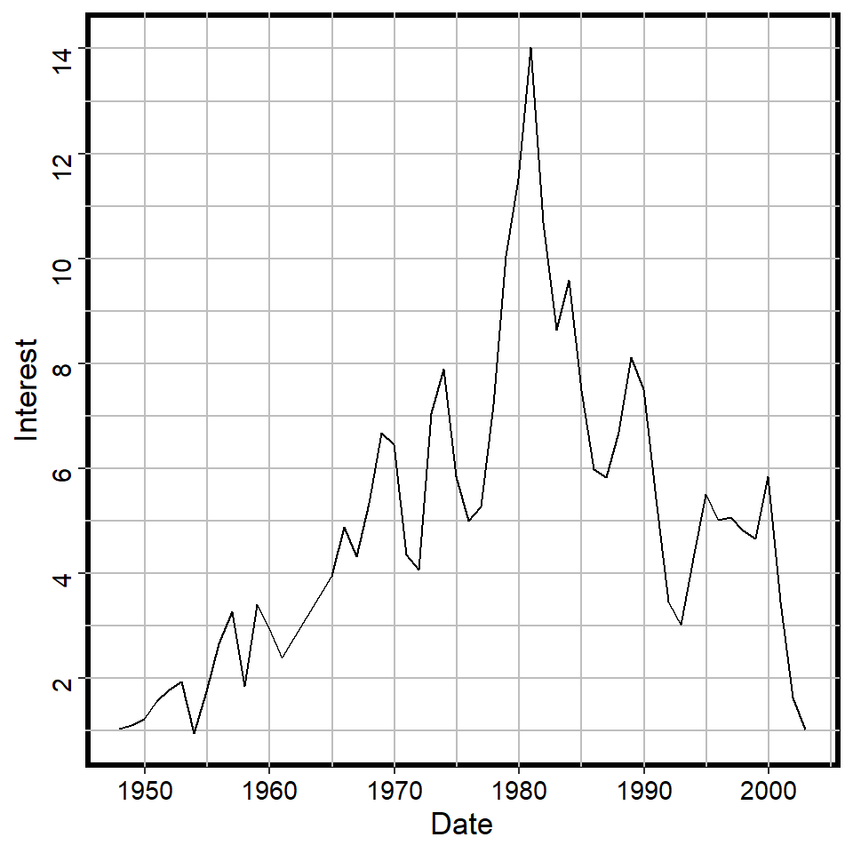

Interest Rate (3-month T-bills)

```r
int_year_zoo_df <- RtsaPkg::tsObj_to_dt(int_year_zoo, wide_form = T)
RplotterPkg::create_scatter_plot(
  df = int_year_zoo_df,
  aes_x = "time",
  aes_y = "i3",
  x_title = "Date",
  y_title = "Interest",
  x_major_breaks = seq.Date(from = as.Date("1950", "%Y"), to = as.Date("2000", "%Y"), by = "10 year"),
  x_date_labels = "%Y",
  y_major_breaks = seq(2,14,2),
  connect = T,
  show_pts = F
)
```

Task: Plot weekly closing prices on Apple stock from 2000 to 2021.

Use *RtsaPkg::get_tiingo_stock_prices* function to get the data from Tiingo as the source.

```r
apple_stocks_dt <- RtsaPkg::get_tiingo_stock_prices(
  symbols = "AAPL",
  from = "2000-01-01",
  to = "2021-01-01",
  periodicity = "weekly"
)
apple_stocks_xts <- RtsaPkg::df_to_xts(
  df = apple_stocks_dt,
  time_col = "Date",
  data_cols = "AdjClose"
)
str(apple_stocks_xts)
```

```
An 'xts' object on 1999-12-31/2021-01-01 containing:
  Data: num [1:1097, 1] 0.781 0.756 0.763 0.846 0.772 ...
 - attr(*, "dimnames")=List of 2
  ..$ : NULL
  ..$ : chr "AdjClose"
  Indexed by objects of class: [Date] TZ: UTC
  xts Attributes:
 NULL
```

Plot the data.

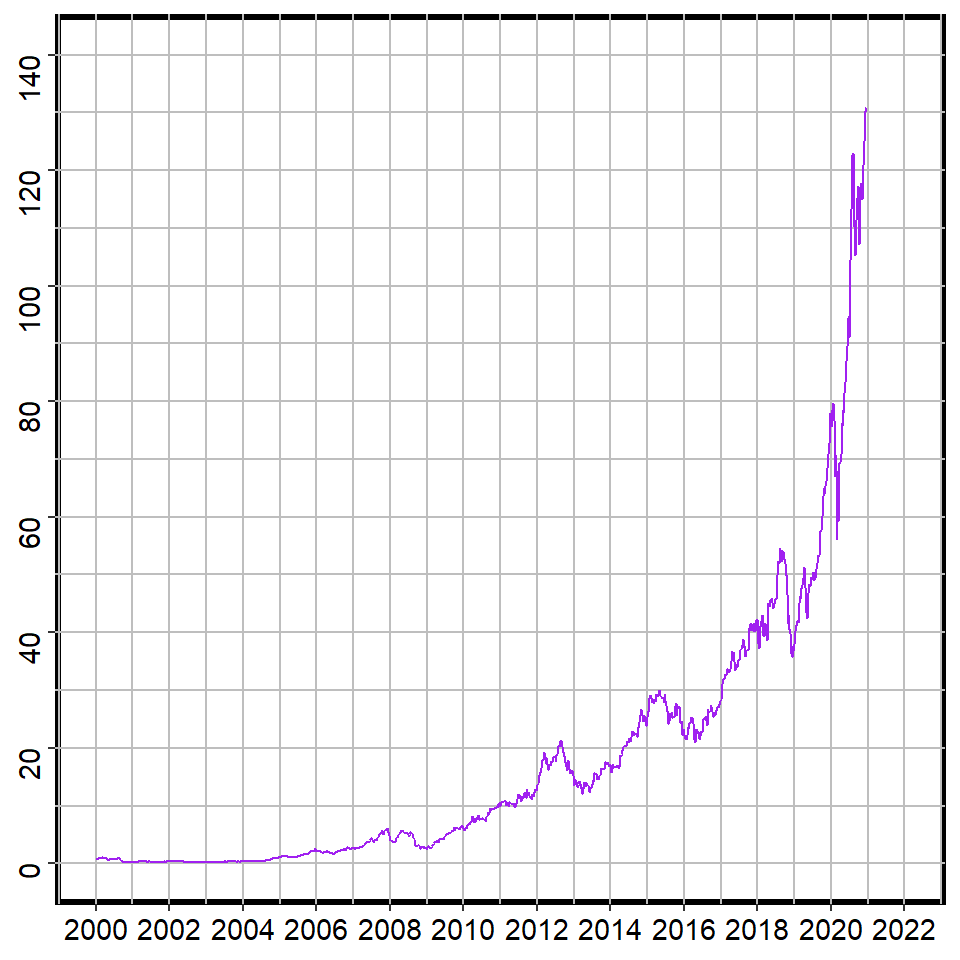

Apple Adjusted Closing Stock Prices

```r
RplotterPkg::create_scatter_plot(
  df = apple_stocks_dt,
  aes_x = "Date",
  aes_y = "AdjClose",
  x_date_labels = "%Y",
  x_limits = c(as.Date("2000", "%Y"), as.Date("2022", "%Y")),
  x_major_breaks = seq(from = as.Date("2000", "%Y"), to = as.Date("2022", "%Y"), by = "2 year"),
  y_major_breaks = seq(0,140,20),
  y_limits = c(0,140),
  x_title = NULL,
  y_title = NULL,
  connect = T,
  show_pts = F,
  line_color = "purple"
)
```

## 10.3 Other Time Series Models

### 10.3.1 The *dynlm::* Package

### 10.3.2 Finite Distributed Lag Models

Task: Model Effects of Personal Tax Exemption on Fertility Rates

Set up the data.

```r
data("fertil3", package = "wooldridge")
```

Define yearly time series beginning in 1913.

```r
fertil3_ts <- ts(fertil3, start = 1913)
str(fertil3_ts)
```

```
 Time-Series [1:72, 1:24] from 1913 to 1984: 125 127 125 123 121 ...
 - attr(*, "dimnames")=List of 2
  ..$ : NULL
  ..$ : chr [1:24] "gfr" "pe" "year" "t" ...
```

Define linear regression model with lags using *dynlm::dynlm()*.

```r
fertil_3_lm <- dynlm::dynlm(gfr ~ pe + L(pe) + L(pe,2) + ww2 + pill, data = fertil3_ts)
```

Summarize *fertil_3_lm*.

```r
summary(fertil_3_lm)
```

```
Time series regression with "ts" data:
Start = 1915, End = 1984

Call:
dynlm::dynlm(formula = gfr ~ pe + L(pe) + L(pe, 2) + ww2 + pill,
    data = fertil3_ts)

Residuals:
     Min       1Q   Median       3Q      Max
-24.6461  -9.5409  -0.0312   8.3378  29.1295

Coefficients:
             Estimate Std. Error t value Pr(>|t|)
(Intercept)  95.87050    3.28196  29.211  < 2e-16 ***
pe            0.07267    0.12553   0.579   0.5647
L(pe)        -0.00578    0.15566  -0.037   0.9705
L(pe, 2)      0.03383    0.12626   0.268   0.7896
ww2         -22.12650   10.73197  -2.062   0.0433 *
pill        -31.30499    3.98156  -7.862 5.63e-11 ***
---
Signif. codes:  0 '***' 0.001 '**' 0.01 '*' 0.05 '.' 0.1 ' ' 1

Residual standard error: 14.27 on 64 degrees of freedom
Multiple R-squared:  0.4986,    Adjusted R-squared:  0.4594
F-statistic: 12.73 on 5 and 64 DF,  p-value: 1.353e-08
```

Perform an $F$-test with the null hypothesis that the lag coefficients equal zero.

```r
car::linearHypothesis(fertil_3_lm,c("pe", "L(pe)", "L(pe, 2)"))
```

```
Linear hypothesis test

Hypothesis:
pe = 0
L(pe) = 0
L(pe, 2) = 0

Model 1: restricted model
Model 2: gfr ~ pe + L(pe) + L(pe, 2) + ww2 + pill

  Res.Df   RSS Df Sum of Sq     F  Pr(>F)
1     67 15460
2     64 13033  3    2427.1 3.973 0.01165 *
---
Signif. codes:  0 '***' 0.001 '**' 0.01 '*' 0.05 '.' 0.1 ' ' 1
```

Task: Repeat the OLS estimate by lagging the data and using *Rregress::ols_calc()*

Convert the data to a *data.table*.

```r
data("fertil3", package = "wooldridge")
fertil3_dt <- data.table::as.data.table(fertil3) %>%
  .[, .(gfr, pe, ww2, pill)]
```

Lag the *pe* predictor by a factor of 2.

```r
fertil3_dt[, c("pe_lag1", "pe_lag2") := shift(pe, 1:2, type = "lag")]
```

Compute the OLS.

```r
formula_obj <- gfr ~ pe + pe_lag1 + pe_lag2 + ww2 + pill
fertil3_ols <- RregressPkg::ols_calc(df = fertil3_dt, formula_obj = formula_obj)
```

```r
RplotterPkg::create_table(
  x = fertil3_ols$coef_df,
  container_width_px = 400
)
```

gfr ~ pe + pe_lag1 + pe_lag2 + ww2 + pill

| Coef | Value | SE | t_value | p_Value |
| --- | --- | --- | --- | --- |
| (Intercept) | 95.870497467 | 3.2819571 | 29.21138071 | 1.022560e-38 |
| pe | 0.072671828 | 0.1255331 | 0.57890569 | 5.646848e-01 |
| pe_lag1 | -0.005779582 | 0.1556629 | -0.03712883 | 9.704979e-01 |
| pe_lag2 | 0.033826844 | 0.1262574 | 0.26791971 | 7.896227e-01 |
| ww2 | -22.126497512 | 10.7319716 | -2.06173649 | 4.329888e-02 |
| pill | -31.304988800 | 3.9815591 | -7.86249501 | 5.633695e-11 |

### 10.3.3 Trends

Task: Include a time predictor in estimating housing investment from prices.

Set up the data.

```r
data("hseinv", package = "wooldridge")
hseinv_dt <- data.table::as.data.table(hseinv) %>%
  .[, .(invpc, year, price)]
```

Compute the OLS.

```r
formula_obj <- log(invpc) ~ year + log(price)
hseinv_ols <- RregressPkg::ols_calc(df = hseinv_dt, formula_obj = formula_obj)
```

```r
RplotterPkg::create_table(
  x = hseinv_ols$coef_df,
  container_width_px = 400
)
```

log(invpc) ~ year + log(price)

| Coef | Value | SE | t_value | p_Value |
| --- | --- | --- | --- | --- |
| (Intercept) | -20.039759954 | 6.96452684 | -2.8774044 | 0.006471953 |
| year | 0.009828726 | 0.00351221 | 2.7984447 | 0.007939359 |
| log(price) | -0.380961330 | 0.67883522 | -0.5611985 | 0.577872803 |